# Reproducible Research: Peer Assessment 1

## Loading and preprocessing data

1. Loading data

```r
rd <- read.csv(unz("activity.zip", "activity.csv"),na.strings = "NA")
```

## What is mean total number of steps taken per day?

1. Histogram of the total number of steps taken each day

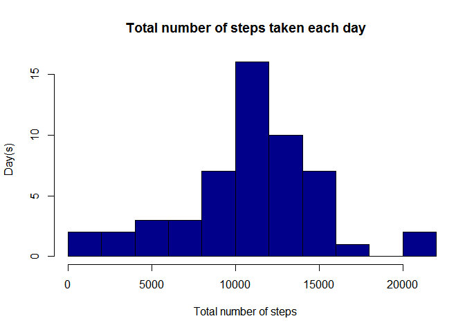

```r
rd_day <- aggregate(rd[1], rd[2], sum)
xmin <- min(rd_day[2],na.rm=TRUE)
xmax <- max(rd_day[2],na.rm=TRUE)
xt <- "Total number of steps"
yt <- "Day(s)"
mt <- "Total number of steps taken each day"
hist(rd_day[is.na(rd_day[2])==FALSE,2], breaks="fd",xlim=c(xmin, xmax),
     main = mt, xlab= xt, ylab=yt, col="Dark Blue")
```

2. the mean and median total number of steps taken per day

```r
mn <- as.integer(mean(rd_day$steps, na.rm=TRUE))
md <- as.integer(median(rd_day$steps, na.rm=TRUE))
md
```

[1] 10765 Mean is **10766** and Median is **10765**

## What is the average daily activity pattern?

1. A time series plot of the 5-minute interval (x-axis) and the average number of steps taken, averaged across all days (y-axis)

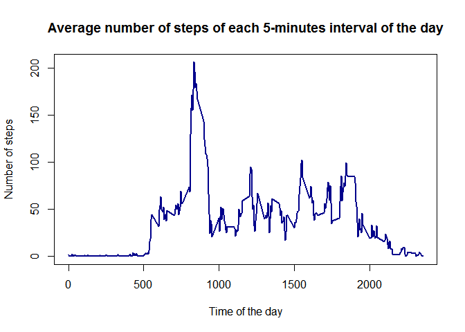

```r
rd_time <- aggregate(rd[1], rd[3], mean, na.rm=TRUE)
xt <- "Time of the day"
yt <- "Number of steps"
mt <- "Average number of steps of each 5-minutes interval of the day"
plot(rd_time[,1], rd_time[,2], type='l',main = mt, xlab= xt, ylab=yt
     ,col = "dark blue", lwd = 2)
```

```r
maxtime <- rd_time[rd_time[2]==max(rd_time[2]),1]
maxtime <- sprintf("%02d:%02d", as.numeric(maxtime) %/% 100, as.numeric(maxtime) %% 60)
```

## Imputing missing values

1. Calculate the total number of missing values in the dataset

```r
NAs <- nrow(rd[is.na(rd[1])==TRUE,])
TN <- nrow(rd[,])
```

Total number of missing values is **2304** out of **17568**

2. Devise a strategy for filling in all of the missing values in the dataset.
- **Use the mean for 5-minute interval to impute missing values**
3. Create a new dataset that is equal to the original dataset but with the missing data filled in.

```r
## to impute use the average of each 5 minutes
## round to decimal point because the number of steps data is Integer
library(data.table)
rd_time2 <- cbind(rd_time[1], round(rd_time[2]))
dt_time <-as.data.table(rd_time2)
dt <-as.data.table(rd)
setkey(dt_time, interval)
setkey(dt, interval)
##Merged data frame data
ipdata <- as.data.frame(merge(dt, dt_time))
##update NA data with the average
ipdata[is.na(ipdata[2])==TRUE,2] <- ipdata[is.na(ipdata[2])==TRUE,4]
```

4. Histogram of the total number of steps taken each day and Calculate and report the mean and median total number of steps taken per day.

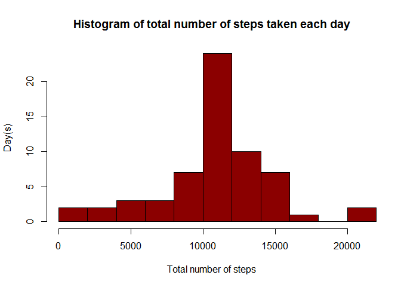

```r
ip_day <- aggregate(ipdata[2], ipdata[3], sum)
xmin <- min(ip_day[2])
xmax <- max(ip_day[2])
xt <- "Total number of steps"
yt <- "Day(s)"
mt <- "Histogram of total number of steps taken each day"
names(ip_day) = c("date", "steps")
hist(ip_day[,2], breaks="fd",xlim=c(xmin, xmax),
     main = mt, xlab= xt, ylab=yt, col="Dark Red")
```

```r
## mean and median after imputing
imn <- as.integer(mean(ip_day$steps))
imd <- as.integer(median(ip_day$steps))
```

Mean is **10765** and Median is **10762**  
(Before imputing, Mean is **10766** and Median is **10765**)

## Are there differences in activity patterns between weekdays and weekends?

1. Create a new factor variable in the dataset with two levels - “weekday” and “weekend” indicating whether a given date is a weekday or weekend day.

```r
ip_week <- cbind(ip_day,weekdays(as.Date(ip_day[,1])))
ip_week2 <- cbind(ip_week, ifelse(!weekdays(as.Date(ip_day[,1])) %in% c("Saturday", "Sunday"), "weekday","weekend"))
names(ip_week2) <- c("date", "Steps", "dayofweek", 'week')

## set weekday or weekend to imputed data
dt2 <- as.data.table(ipdata[1:3])
setkey(dt2, date)
dt_ip2 <- as.data.table(ip_week2[c(1,4)])
dt_ip <- as.data.frame(merge(dt2, dt_ip2))
```

2. Make a panel plot containing a time series plot of the 5-minute interval (x-axis) and the average number of steps taken, averaged across all weekday days or weekend days (y-axis).

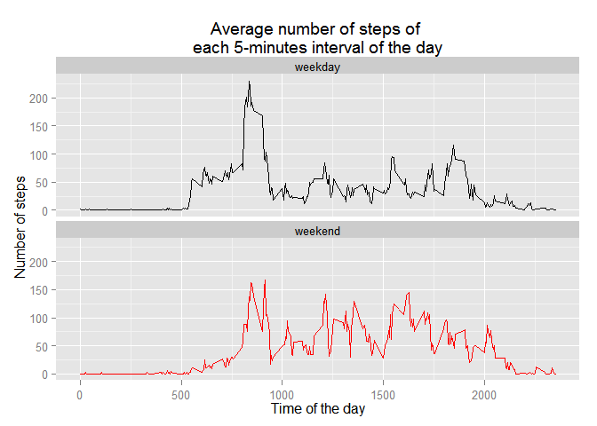

```r
## calculate steps by interval and weekday or weekend
library(ggplot2)
dt_time_week <- aggregate(dt_ip[3], c(dt_ip[4],dt_ip[2]), mean)
xt <- "Time of the day"
yt <- "Number of steps"
mt <- "Average number of steps of \neach 5-minutes interval of the day"
names(dt_time_week) = c("week", "interval", "steps")
ggplot(dt_time_week, aes(interval, steps,col=week)) + facet_wrap(~week,nrow=2) + geom_line(aes(group=week)) + labs(x=xt, y= yt, title =mt) + theme(legend.position = "none") + scale_color_manual(values = c("black", "red"))
```